# Strategy to Launch Historical Funding

Below is the historical performance of the Strategy-to-Launch life cycle in the BAT.

Comparing the data from STL reporting and the BAT’s Digital Portfolio Governance (DPG) reporting. Some variance was found in the planned vs. executed project reporting in the datasets but trends are consistent.

```
## # A tibble: 8 × 11
##   FY    Roadmap_projects Roadmap_amounts Self_projects Self_amounts
##   <chr>            <dbl>           <dbl>         <dbl>        <dbl>
## 1 FY18                 5            1380             1          231
## 2 FY19                14            6940             3          684
## 3 FY20                39           17745             5         1349
## 4 FY21                32           19441             2         1059
## 5 FY22                 3            6570             6         1321
## 6 FY23                 4            2497             7         1750
## 7 FY24                 3            3370             5          799
## 8 FY25                 5           11000             8         1500
## # ℹ 6 more variables: Total_projects <dbl>, Total <dbl>,
## #   `Transform_demands-STL` <dbl>, `Approved-STL` <dbl>, `Self-fund-STL` <dbl>,
## #   `Total-STL` <dbl>
```

Table 1. Raw DPG & STL data

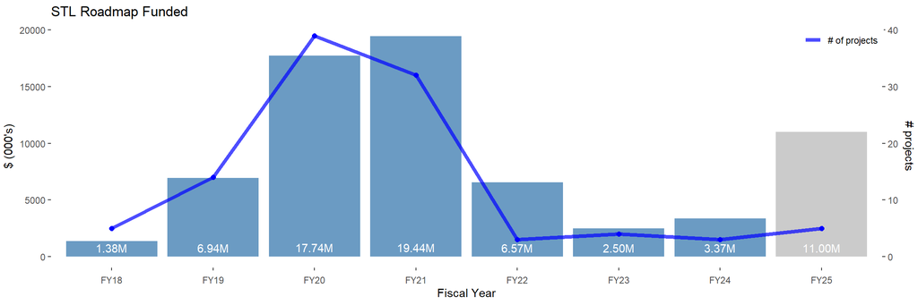

Figure 1. Roadmap funded projects and funding levels each fiscal year.

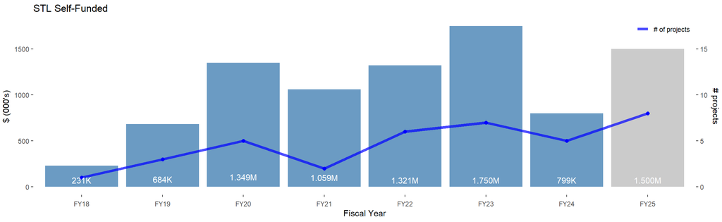

Figure 2. Self-funded projects and cost each fiscal year.

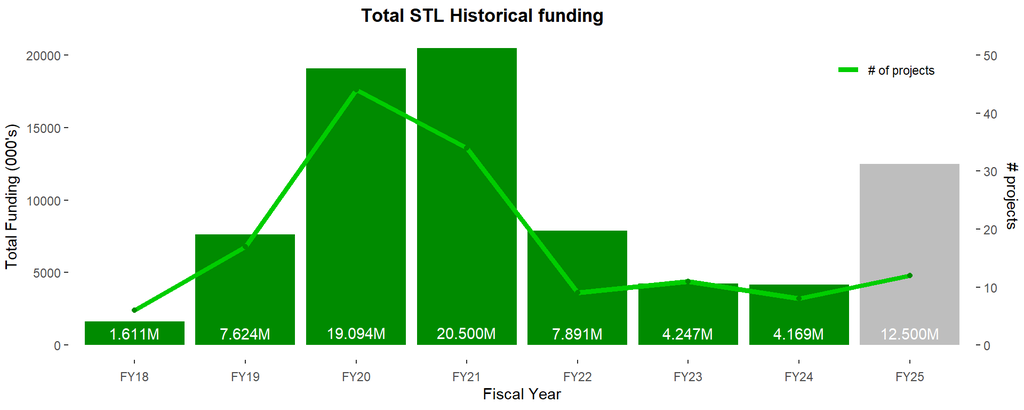

Fig 3. STL project totals by fiscal year.

**Findings**

The differences in the DPG and STL datasets are not too disparate; attributing most of the differences to snapshots in time; whether before or after a key decision, trends are the same. Using the DPG data will result in have less friction in future discussions. Depicted as such.

Funding for certain IT systems, like Windchill, has also shifted. Dell Digital does not provide support as it did in 2018 and 2020 when STL funded those upgrades.